# Agglomerative Clustering

### Hierarchical Clustering:

- Hierarchical clustering algorithms group similar objects into groups called clusters.

### There are two types of hierarchical clustering algorithms:

1. **Agglomerative:** Bottom up approach. Start with many small clusters and merge them together to create bigger clusters.
2. **Divisive:** Top down approach. Start with a single cluster then break it up into smaller clusters.

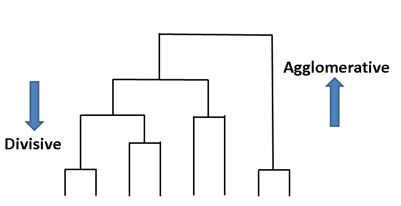

### Pros and Cons of Hierarchical Clustering

#### Pros:

- No assumption of a particular number of cluster, like in K-means.
- Many correspond to meaningful taxonomies.

#### Cons:

- Once a decision is made to combine two cluster, it can't be undone.
- Very slow for large data sets, **O($n^2$log(n))**.

#### Working:

1. Make each data point a cluster.
2. Take the two closest cluster and make them one cluster.
3. Repeat step 2 until there is only one cluster.

```python
import pandas as pd
import numpy as np
import matplotlib.pyplot as plt
import seaborn as sns
import warnings
warnings.filterwarnings('ignore')
```

```python
df= pd.read_csv('Mall_Customers.csv')
df.head()
```

|  | CustomerID | Gender | Age | Annual Income (k$) | Spending Score (1-100) |
| --- | --- | --- | --- | --- | --- |
| 0 | 1 | Male | 19 | 15 | 39 |
| 1 | 2 | Male | 21 | 15 | 81 |
| 2 | 3 | Female | 20 | 16 | 6 |
| 3 | 4 | Female | 23 | 16 | 77 |
| 4 | 5 | Female | 31 | 17 | 40 |

```python
data= df.iloc[:, 3:5]
```

```python
import scipy.cluster.hierarchy as sch
```

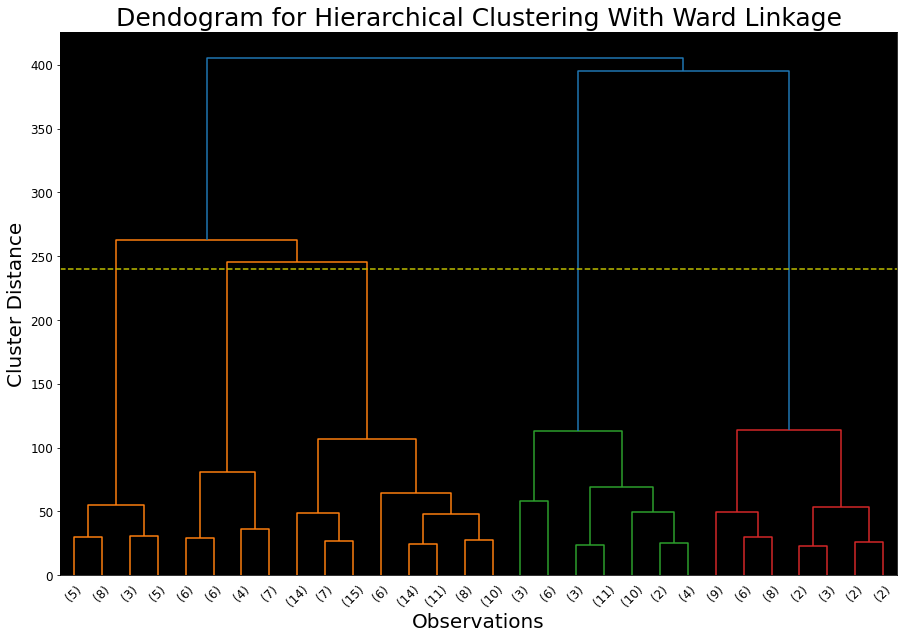

```python
plt.figure(figsize= (15,10))
ax= plt.axes()
ax.set_facecolor('black')
ax= dendo= sch.dendrogram(sch.linkage(data, method= 'ward'), truncate_mode= 'lastp', show_leaf_counts= True)
plt.axhline(y=240, color= 'y', linestyle= '--')
plt.title('Dendogram for Hierarchical Clustering With Ward Linkage', fontsize=25)
plt.xlabel('Observations', fontsize=20)
plt.ylabel('Cluster Distance', fontsize=20)
plt.xticks(fontsize= 12);
plt.yticks(fontsize=12);
plt.show()
```

```python
from sklearn.cluster import AgglomerativeClustering
```

```python
agl= AgglomerativeClustering(n_clusters=5, affinity= 'euclidean', linkage= 'ward')
lables_= agl.fit_predict(data)
```

```python
lable= list(lables_)
```

```python
data['Cluster']= lable
data.head()
```

|  | Annual Income (k$) | Spending Score (1-100) | Cluster |
| --- | --- | --- | --- |
| 0 | 15 | 39 | 4 |
| 1 | 15 | 81 | 3 |
| 2 | 16 | 6 | 4 |
| 3 | 16 | 77 | 3 |
| 4 | 17 | 40 | 4 |

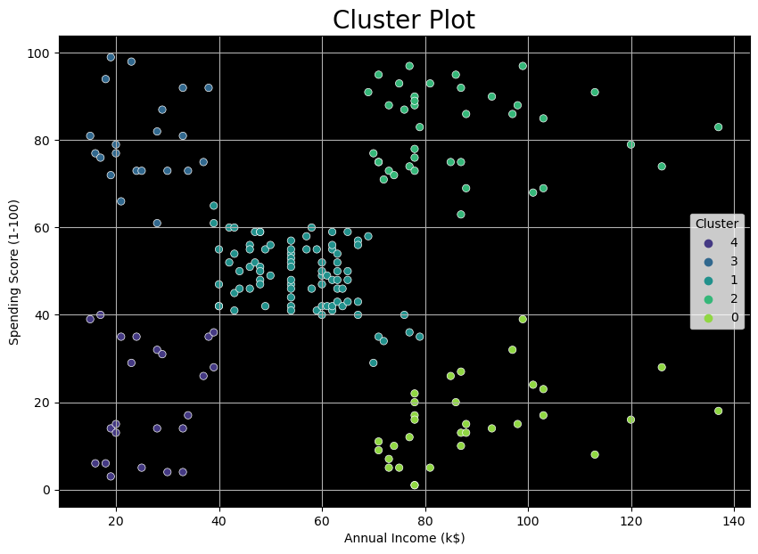

```python
plt.figure(figsize=(10,7), dpi=100)
ax= plt.axes()
ax.set_facecolor('black')
sns.scatterplot(data['Annual Income (k$)'], data['Spending Score (1-100)'], hue= data['Cluster'], palette= 'viridis')
plt.grid()
plt.title('Cluster Plot', fontsize= 20)
```

### Scatter_Plot with Plotly

```python
import plotly.express as px
data['Cluster']= data['Cluster'].astype(str)
fig= px.scatter(data, x= 'Annual Income (k$)',
               y= 'Spending Score (1-100)',
               color= 'Cluster',
               color_discrete_sequence = px.colors.qualitative.Set1)

fig.update_traces(marker= dict(size= 10, opacity= 0.80))

fig.update_layout(
        template= 'plotly_dark',
        width= 800,
        legend_title= 'Clusters',
        title= dict(
           text= '<b>Hierarchical Agglomerative Clustering</b>',
           x= 0.5,
           y= 0.95,
           font= dict(
             size= 20
           )
        ),
    xaxis_title= '<b> Annual Income</b>',
    yaxis_title= '<b>Sum of Spending Scores</b>'
        )


fig.show()
```

[interactive chart not shown]